# DMIS and Xiaoping top predictions - similarity analysis

Robert Allaway, Sage Bionetworks

2019-09-18

The top compounds selected by each team had binding in kinase assays, but did not have activity in flies. To test some other compounds, we requested the top 100 compounds from each team. One team (Zhaoping) sent us more than 100 because their scoring metric was integer based - eg. after the first few, many compounds had the same ranking - so we received the top 253 and 443 compounds for P1 and P2 from this team, respectively. DMIS-MTD sent us the top 100 for each problem. Note that their method has stochastic steps, so their results may differ from the challenge submission. Unlike the challenge, there were no identical predictions across the two sets.

## Problem 1

[output not shown]

Then, we took all interactions where the tanimoto score to any compound in the other dataset was greater than 0.4 (selected simply for ease of visualization) and converted this data to network. Larger weights indicate a larger tanimoto score. Yellow nodes are DMIS, blue nodes are Zhaoping.

[interactive chart not shown]

## Problem 2

We processed all of the P2 compounds and clustered the similarity matrix. Here, the rows are DMIS-MTD predictions and the columns are Zhaoping’s predictions.

[output not shown]

[output cut: 1757 more lines]

[output not shown]

[output cut: 45 more lines]

[output not shown]

[output not shown]

[output cut: 385 more lines]

[figure not shown]

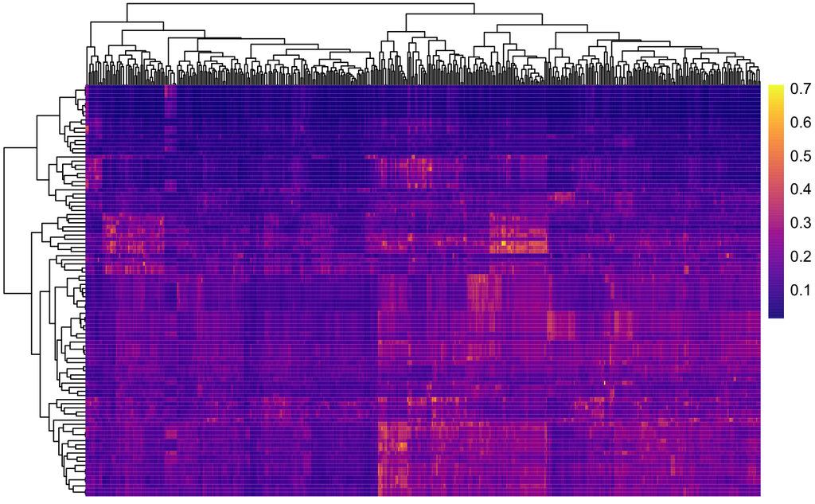

Then, we took all interactions where the tanimoto score to any compound in the other dataset was greater than 0.4 (selected simply for ease of visualization) and converted this data to network. Larger weights indicate a larger tanimoto score. Yellow nodes are DMIS, blue nodes are Zhaoping.

[interactive chart not shown]